# salary-analysis

2023-12-15

## R Markdown

Hypotheses 1) The initial hypothesis postulates a significant correlation between early career pays and the presence of STEM programs or tuition fees. This posits that higher STEM percentages and higher fees might lead to higher early career pays. 2) Another hypothesis assumes that the combined effect of STEM percentages and tuition fees collectively explains more variability in early career pays than STEM percentages alone. This implies that considering both factors together enhances the understanding of early career pays. 3) The third hypothesis suggests that graduates from private universities exhibit a significantly higher early career pay compared to their counterparts from public universities. This implies an anticipated disparity in salary outcomes based on the type of institution attended.

#Reading the data

```r
url <- 'https://raw.githubusercontent.com/rfordatascience/tidytuesday/master/data/2020/2020-03-10/salary_potential.csv'
salary_potential <- readr::read_csv(url)
nrow(salary_potential)
```

```
## [1] 935
```

```r
url2 <- 'https://raw.githubusercontent.com/rfordatascience/tidytuesday/master/data/2020/2020-03-10/tuition_cost.csv'
tuition_cost <- readr::read_csv(url2)
nrow(tuition_cost)
```

```
## [1] 2973
```

## Merging the two data tables

```r
uni_data <- salary_potential%>%
  left_join(tuition_cost, by = "name")
head(uni_data)
```

```
## # A tibble: 6 × 16
##    rank name   state_name early_career_pay mid_career_pay make_world_better_pe…¹
##   <dbl> <chr>  <chr>                 <dbl>          <dbl>                  <dbl>
## 1     1 Aubur… Alabama               54400         104500                     51
## 2     2 Unive… Alabama               57500         103900                     59
## 3     3 The U… Alabama               52300          97400                     50
## 4     4 Tuske… Alabama               54500          93500                     61
## 5     5 Samfo… Alabama               48400          90500                     52
## 6     6 Sprin… Alabama               46600          89100                     53
## # ℹ abbreviated name: ¹make_world_better_percent
## # ℹ 10 more variables: stem_percent <dbl>, state <chr>, state_code <chr>,
## #   type <chr>, degree_length <chr>, room_and_board <dbl>,
## #   in_state_tuition <dbl>, in_state_total <dbl>, out_of_state_tuition <dbl>,
## #   out_of_state_total <dbl>
```

```r
str(uni_data)
```

```
## spc_tbl_ [939 × 16] (S3: spec_tbl_df/tbl_df/tbl/data.frame)
##  $ rank                     : num [1:939] 1 2 3 4 5 6 7 8 9 10 ...
##  $ name                     : chr [1:939] "Auburn University" "University of Alabama in Huntsville" "The University of Alabama" "Tuskegee University" ...
##  $ state_name               : chr [1:939] "Alabama" "Alabama" "Alabama" "Alabama" ...
##  $ early_career_pay         : num [1:939] 54400 57500 52300 54500 48400 46600 49100 48600 47700 48700 ...
##  $ mid_career_pay           : num [1:939] 104500 103900 97400 93500 90500 ...
##  $ make_world_better_percent: num [1:939] 51 59 50 61 52 53 48 57 56 58 ...
##  $ stem_percent             : num [1:939] 31 45 15 30 3 12 27 17 17 20 ...
##  $ state                    : chr [1:939] "Alabama" "Alabama" NA "Alabama" ...
##  $ state_code               : chr [1:939] "AL" "AL" NA "AL" ...
##  $ type                     : chr [1:939] "Public" "Public" NA "Private" ...
##  $ degree_length            : chr [1:939] "4 Year" "4 Year" NA "4 Year" ...
##  $ room_and_board           : num [1:939] 13332 10094 NA 9650 10550 ...
##  $ in_state_tuition         : num [1:939] 11276 10714 NA 22170 31650 ...
##  $ in_state_total           : num [1:939] 24608 20808 NA 31820 42200 ...
##  $ out_of_state_tuition     : num [1:939] 30524 22362 NA 22170 31650 ...
##  $ out_of_state_total       : num [1:939] 43856 32456 NA 31820 42200 ...
##  - attr(*, "spec")=
##   .. cols(
##   ..   rank = col_double(),
##   ..   name = col_character(),
##   ..   state_name = col_character(),
##   ..   early_career_pay = col_double(),
##   ..   mid_career_pay = col_double(),
##   ..   make_world_better_percent = col_double(),
##   ..   stem_percent = col_double()
##   .. )
##  - attr(*, "problems")=<externalptr>
```

```r
summary(uni_data)
```

```
##       rank           name            state_name        early_career_pay
##  Min.   : 1.00   Length:939         Length:939         Min.   :32500
##  1st Qu.: 5.00   Class :character   Class :character   1st Qu.:46000
##  Median :11.00   Mode  :character   Mode  :character   Median :50000
##  Mean   :11.48                                         Mean   :51353
##  3rd Qu.:17.00                                         3rd Qu.:55550
##  Max.   :25.00                                         Max.   :91200
##
##  mid_career_pay   make_world_better_percent  stem_percent       state
##  Min.   : 60100   Min.   :33.00             Min.   :  0.00   Length:939
##  1st Qu.: 81650   1st Qu.:48.00             1st Qu.:  7.00   Class :character
##  Median : 89900   Median :52.00             Median : 13.00   Mode  :character
##  Mean   : 92798   Mean   :53.89             Mean   : 16.91
##  3rd Qu.:100700   3rd Qu.:58.00             3rd Qu.: 23.00
##  Max.   :158200   Max.   :94.00             Max.   :100.00
##                   NA's   :35
##   state_code            type           degree_length      room_and_board
##  Length:939         Length:939         Length:939         Min.   : 1698
##  Class :character   Class :character   Class :character   1st Qu.: 8931
##  Mode  :character   Mode  :character   Mode  :character   Median :10494
##                                                           Mean   :10882
##                                                           3rd Qu.:12862
##                                                           Max.   :18156
##                                                           NA's   :249
##  in_state_tuition in_state_total  out_of_state_tuition out_of_state_total
##  Min.   : 4118    Min.   : 4258   Min.   : 4118        Min.   : 6670
##  1st Qu.: 9930    1st Qu.:19388   1st Qu.:20682        1st Qu.:29536
##  Median :25506    Median :34116   Median :28844        Median :38780
##  Mean   :26272    Mean   :36586   Mean   :30656        Mean   :40971
##  3rd Qu.:40076    3rd Qu.:52183   3rd Qu.:40576        3rd Qu.:52683
##  Max.   :58230    Max.   :75003   Max.   :58230        Max.   :75003
##  NA's   :211      NA's   :211     NA's   :211          NA's   :211
```

```r
view(uni_data)
nrow(uni_data)
```

```
## [1] 939
```

#Handling missing values

```r
na_rows <- rowSums(is.na(uni_data))
na_count <- sum(na_rows > 0)
print(na_count)
```

```
## [1] 269
```

```r
cleaned_data <- na.omit(uni_data)
nrow(cleaned_data)
```

```
## [1] 670
```

#Exploratory data analysis

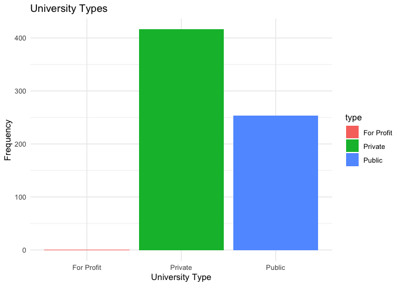

```r
ggplot(cleaned_data, aes(x = type, fill = type)) +
  geom_bar() +
  labs(x = "University Type", y = "Frequency", title = "University Types") +
  theme_minimal()
```

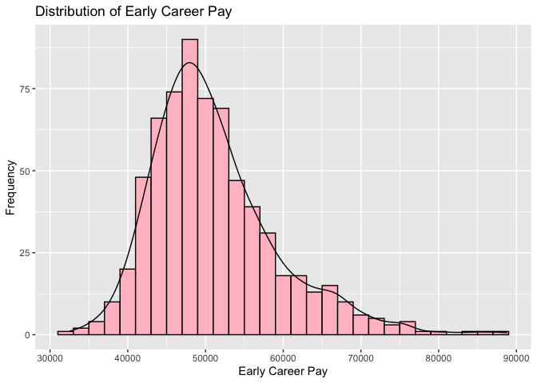

```r
ggplot(cleaned_data, aes(x = early_career_pay)) +
  geom_histogram(binwidth = 2000, fill = "pink", color = "black") +
  geom_density(aes(y = ..count.. * 2000), color = "black") +
  labs(x = "Early Career Pay", y = "Frequency", title = "Distribution of Early Career Pay")
```

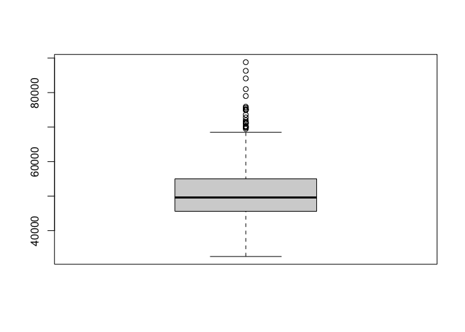

```r
boxplot(cleaned_data$early_career_pay)
```

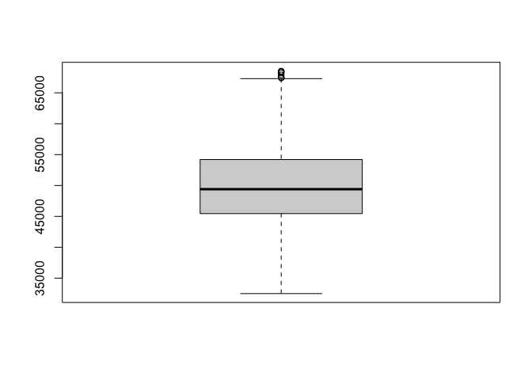

```r
cleaned_early_career_pay <- cleaned_data$early_career_pay[!cleaned_data$early_career_pay %in% boxplot.stats(cleaned_data$early_career_pay)$out]
cleaned_data$cleaned_early_career_pay <- ifelse(cleaned_data$early_career_pay %in% cleaned_early_career_pay, cleaned_data$early_career_pay, NA)
boxplot(cleaned_data$cleaned_early_career_pay)
```

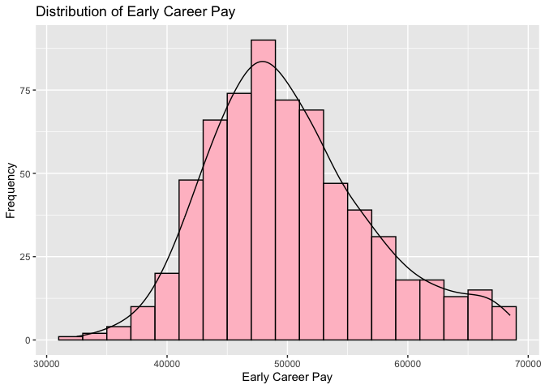

```r
ggplot(cleaned_data, aes(x = cleaned_early_career_pay)) +
  geom_histogram(binwidth = 2000, fill = "pink", color = "black") +
  geom_density(aes(y = ..count.. * 2000), color = "black") +
  labs(x = "Early Career Pay", y = "Frequency", title = "Distribution of Early Career Pay")
```

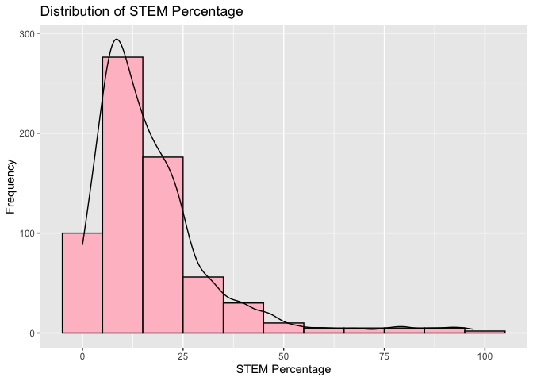

```r
ggplot(cleaned_data, aes(x = stem_percent)) +
  geom_histogram(binwidth = 10, fill = "pink", color = "black") +
  geom_density(aes(y = ..count.. * 10), color = "black") +
  labs(x = "STEM Percentage", y = "Frequency", title = "Distribution of STEM Percentage")
```

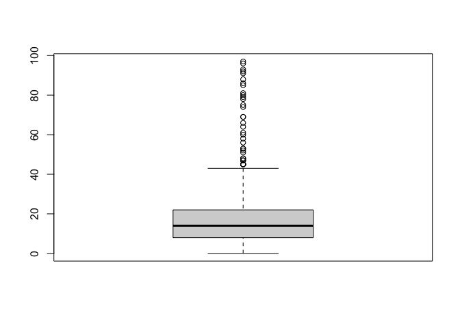

```r
boxplot(cleaned_data$stem_percent)
```

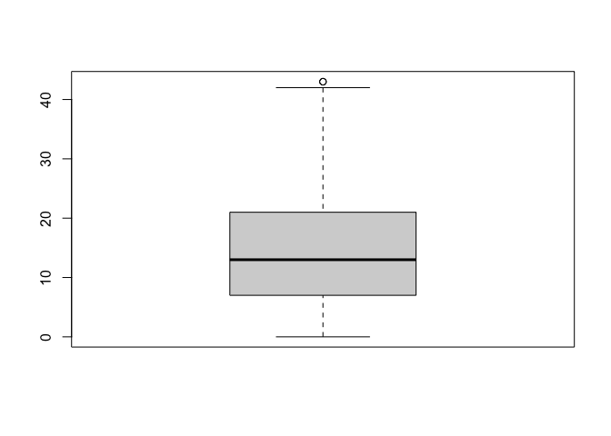

```r
cleaned_stem_percent <- cleaned_data$stem_percent[!cleaned_data$stem_percent %in% boxplot.stats(cleaned_data$stem_percent)$out]
cleaned_data$cleaned_stem_percent <- ifelse(cleaned_data$stem_percent %in% cleaned_stem_percent, cleaned_data$stem_percent, NA)
boxplot(cleaned_data$cleaned_stem_percent)
```

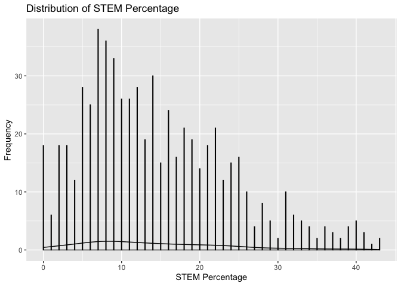

```r
ggplot(cleaned_data, aes(x = cleaned_stem_percent)) +
  geom_histogram(binwidth = 0.05, fill = "pink", color = "black") +
  geom_density(aes(y = ..count.. * 0.05), color = "black") +
  labs(x = "STEM Percentage", y = "Frequency", title = "Distribution of STEM Percentage")
```

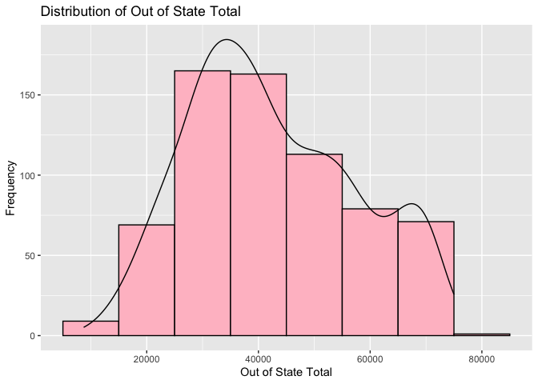

```r
ggplot(cleaned_data, aes(x = out_of_state_total)) +
  geom_histogram(binwidth = 10000, fill = "pink", color = "black") +
  geom_density(aes(y = ..count.. * 10000), color = "black") +
  labs(x = "Out of State Total", y = "Frequency", title = "Distribution of Out of State Total")
```

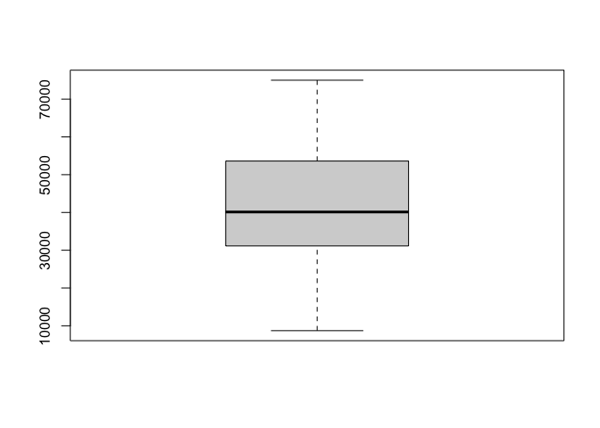

```r
boxplot(cleaned_data$out_of_state_total)
```

```
## Warning: Removed 47 rows containing non-finite values (`stat_smooth()`).

## Warning: Removed 47 rows containing missing values (`geom_point()`).
```

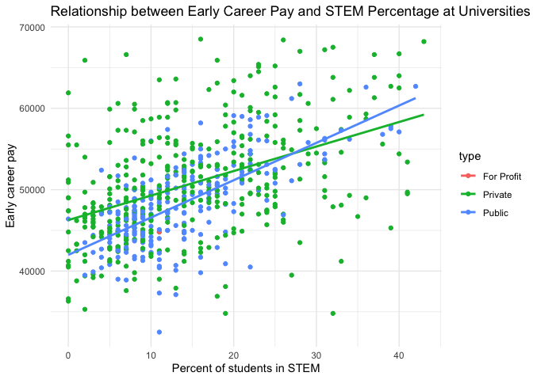

```r
ggplot(cleaned_data, aes(x = cleaned_stem_percent, y = cleaned_early_career_pay, color = type)) +
  geom_point() +
  geom_smooth(method = "lm", se = FALSE) +
  labs(x = "Percent of students in STEM", y = "Early career pay", title = "Relationship between Early Career Pay and STEM Percentage at Universities") +
  theme_minimal()
```

```
## Warning: Removed 23 rows containing non-finite values (`stat_smooth()`).

## Warning: Removed 23 rows containing missing values (`geom_point()`).
```

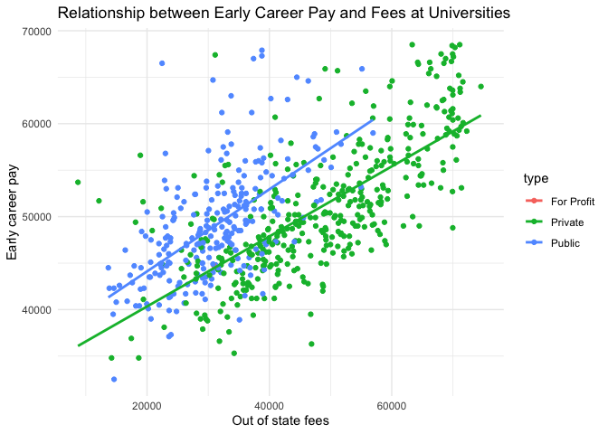

```r
ggplot(cleaned_data, aes(x = out_of_state_total, y = cleaned_early_career_pay, color = type)) +
  geom_point() +
  geom_smooth(method = "lm", se = FALSE) +
  labs(x = "Out of state fees", y = "Early career pay", title = "Relationship between Early Career Pay and Fees at Universities") +
  theme_minimal()
```

#Creating a linear model to explore the relationship between early career pay and the percentage of STEM graduates/out-of-state fees

```r
base_m <- lm (cleaned_early_career_pay ~ cleaned_stem_percent + out_of_state_total, data=cleaned_data)
summary(base_m)
```

```
##
## Call:
## lm(formula = cleaned_early_career_pay ~ cleaned_stem_percent +
##     out_of_state_total, data = cleaned_data)
##
## Residuals:
##      Min       1Q   Median       3Q      Max
## -14209.8  -2975.5    172.8   2669.3  16843.3
##
## Coefficients:
##                       Estimate Std. Error t value Pr(>|t|)
## (Intercept)          3.654e+04  5.508e+02   66.34   <2e-16 ***
## cleaned_stem_percent 2.093e+02  2.039e+01   10.26   <2e-16 ***
## out_of_state_total   2.464e-01  1.324e-02   18.60   <2e-16 ***
## ---
## Signif. codes:  0 '***' 0.001 '**' 0.01 '*' 0.05 '.' 0.1 ' ' 1
##
## Residual standard error: 4427 on 620 degrees of freedom
##   (47 observations deleted due to missingness)
## Multiple R-squared:  0.5241, Adjusted R-squared:  0.5225
## F-statistic: 341.3 on 2 and 620 DF,  p-value: < 2.2e-16
```

#Testing the assumptions of multiple linear regression

```r
cooks_distance <- cooks.distance(base_m)
cooks_distance
```

[output not shown]

[output cut: 153 more lines]

[output not shown]

```r
cooks.distance(base_m)[which.max(cooks.distance(base_m))] #ID
```

```
##        341
## 0.04973892
```

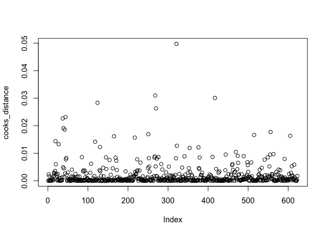

```r
plot(cooks_distance)
```

```r
residuals <- resid(base_m)
shapiro.test(base_m$residuals)
```

```
##
##  Shapiro-Wilk normality test
##
## data:  base_m$residuals
## W = 0.99631, p-value = 0.1564
```

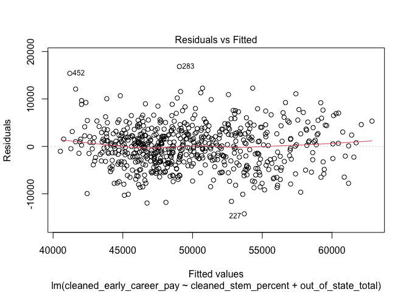

```r
plot(base_m, 1)
```

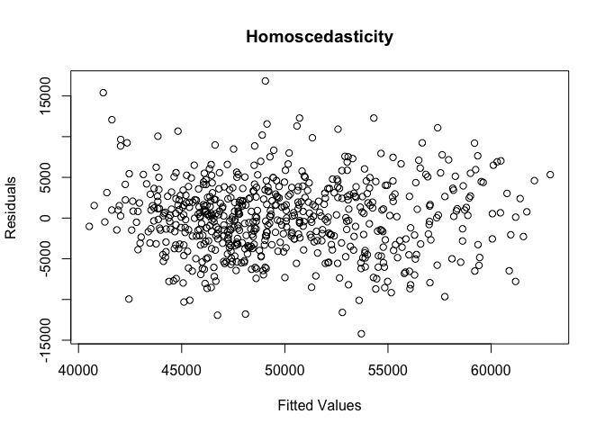

```r
fitted_values <- fitted(base_m)
plot(fitted_values, residuals,
     xlab = "Fitted Values",
     ylab = "Residuals",
     main = "Homoscedasticity")
```

```r
vif(base_m)
```

```
## cleaned_stem_percent   out_of_state_total
##             1.154812             1.154812
```

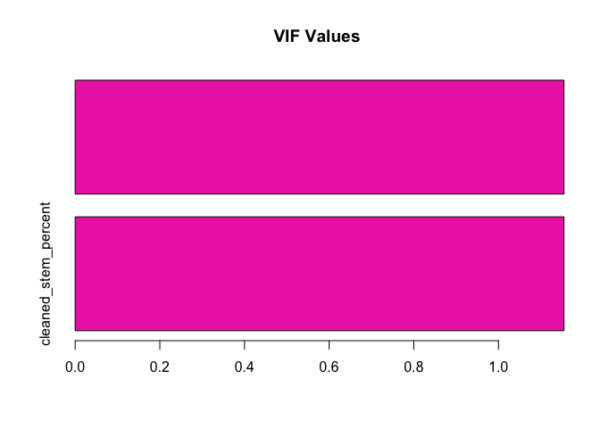

```r
vif_values <- vif(base_m)
barplot(vif_values, main = "VIF Values", horiz = TRUE, col = "#ee36b4")
```

Based on the test there are no influential outliers impacting the model significantly Based on the p-value, the residuals reasonably approximate a normal distribution Based on the plot the linearity assumption is met Based on the graphical representation, we can assume that the homoscedasticity assumption is met Based on the VIF values, there is no multicollinearity detected.”

#Building the linear regression models

```
##
## Call:
## lm(formula = cleaned_early_career_pay ~ cleaned_stem_percent,
##     data = cleaned_data)
##
## Residuals:
##      Min       1Q   Median       3Q      Max
## -21131.0  -3427.0   -430.7   2754.3  20413.8
##
## Coefficients:
##                      Estimate Std. Error t value Pr(>|t|)
## (Intercept)          44789.85     407.45  109.93   <2e-16 ***
## cleaned_stem_percent   348.16      23.66   14.71   <2e-16 ***
## ---
## Signif. codes:  0 '***' 0.001 '**' 0.01 '*' 0.05 '.' 0.1 ' ' 1
##
## Residual standard error: 5521 on 621 degrees of freedom
##   (47 observations deleted due to missingness)
## Multiple R-squared:  0.2585, Adjusted R-squared:  0.2573
## F-statistic: 216.4 on 1 and 621 DF,  p-value: < 2.2e-16

##
## Call:
## lm(formula = cleaned_early_career_pay ~ cleaned_stem_percent +
##     out_of_state_total, data = cleaned_data)
##
## Residuals:
##      Min       1Q   Median       3Q      Max
## -14209.8  -2975.5    172.8   2669.3  16843.3
##
## Coefficients:
##                       Estimate Std. Error t value Pr(>|t|)
## (Intercept)          3.654e+04  5.508e+02   66.34   <2e-16 ***
## cleaned_stem_percent 2.093e+02  2.039e+01   10.26   <2e-16 ***
## out_of_state_total   2.464e-01  1.324e-02   18.60   <2e-16 ***
## ---
## Signif. codes:  0 '***' 0.001 '**' 0.01 '*' 0.05 '.' 0.1 ' ' 1
##
## Residual standard error: 4427 on 620 degrees of freedom
##   (47 observations deleted due to missingness)
## Multiple R-squared:  0.5241, Adjusted R-squared:  0.5225
## F-statistic: 341.3 on 2 and 620 DF,  p-value: < 2.2e-16

##           Model Adjusted_R_squared F_statistic df_model df_residuals      AIC
## 1  Simple Model          0.2572660    216.4465        1          621 12508.03
## 2 Complex Model          0.5225273    341.3461        2          620 12233.77

## Analysis of Variance Table
##
## Model 1: cleaned_early_career_pay ~ cleaned_stem_percent
## Model 2: cleaned_early_career_pay ~ cleaned_stem_percent + out_of_state_total
##   Res.Df        RSS Df  Sum of Sq   F    Pr(>F)
## 1    621 1.8932e+10
## 2    620 1.2151e+10  1 6781148311 346 < 2.2e-16 ***
## ---
## Signif. codes:  0 '***' 0.001 '**' 0.01 '*' 0.05 '.' 0.1 ' ' 1
```

The complex model exhibits a notably higher adjusted R-squared (0.5225) compared to the simpler model (0.2573). This suggests that the additional predictor in the complex model contributes to explaining more variation in the dependent variable. The likelihood-ratio test’s F-statistic of 346 with a low p-value (< 2.2e-16) indicates that adding ‘out_of_state_total’ alongside ‘cleaned_stem_percent’ significantly enhances the model fit. The AIC value for the complex model (12233.77) is lower, suggesting a better trade-off between goodness of fit and model complexity compared to the AIC value for the simpler model (12508.03). The likelihood ratio test indicates a significant improvement in fit by adding predictors to the model. The p-value (< 2.2e-16) strongly suggests that the complex model provides a better fit compared to the simpler model.

#Examining differences in early career pays between private and public universities.

```
## [1] "1" "2"

##
##  Wilcoxon rank sum test with continuity correction
##
## data:  cleaned_early_career_pay by type
## W = 41468, p-value = 0.0004563
## alternative hypothesis: true location shift is not equal to 0

##   type cleaned_early_career_pay.mean cleaned_early_career_pay.median
## 1    1                     49077.689                       48300.000
## 2    2                     51052.658                       50000.000
##   cleaned_early_career_pay.sd cleaned_early_career_pay.min
## 1                    6081.018                    32500.000
## 2                    7139.179                    34800.000
##   cleaned_early_career_pay.max
## 1                    67900.000
## 2                    68500.000
```

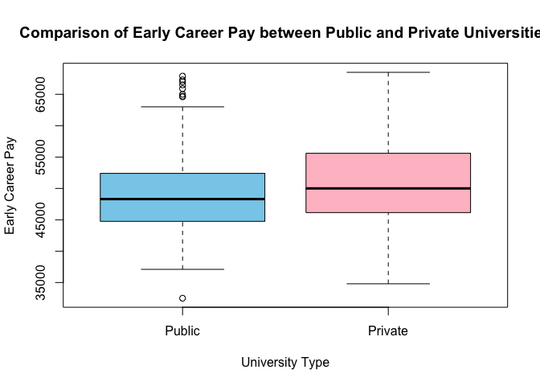

The statistics indicate a difference in the early career pay between public (1) and private (2) universities. Specifically, the median early career pay for public universities stands at $48,300, while for private universities, it’s $50,000. The mean early career pay for public universities is approximately $49,077.69, whereas for private universities, it’s roughly $51,052.66. The Wilcoxon rank sum test, comparing these two types, yields a significant p-value of 0.0004563, suggesting a notable shift in the early career pay between public and private universities.